# metaHelper_analysis

## Setting up Environment

This analysis requires the packages tidyverse, brms and tidybayes.

```r
set.seed(1)

library("broom.mixed")
library("tidyverse")
library("brms")
library("tidybayes")
dat_result <- read.csv("dat_result.csv", stringsAsFactors = FALSE)

dat_result <- dat_result %>%
  mutate(group = gsub("Intervention", "metaHelper", group))

# this dataframe is used for visualization only. It provides the background colors for the exploratory plots.
group_shading_dat <- data.frame(
  ID = c(0, 0),
  result = c(0,0),
  x_min = c(1, 1),
  x_max = c(1, 1),
  y_min = c(0, 0),
  y_max = c(0, 0),
  Group = c("metaHelper", "Control")
)
```

## Exploratory analysis

### Correct answers

Show the frequency of answers

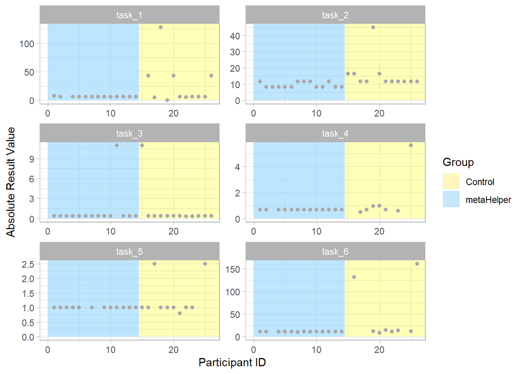

```r
dat_result %>%
  ggplot(aes(x = ID, y = abs(result))) +
  geom_rect(aes(xmin = min(ID), xmax = max(ID), ymin = 0, ymax = max(result), fill = group),  alpha = 0.2) +
  #first geom_rect is just used to create the legend
  geom_rect(data = group_shading_dat, aes(xmin = x_min, xmax = x_max, ymin = y_min, ymax = y_max, fill = Group),  alpha = 0.2) +
  geom_rect(xmin = 0, xmax = 14.5, ymin = 0, ymax = 500, fill = "#5BC0EB",  alpha = 0.02) +
  geom_rect(xmin = 14.5, xmax = 500, ymin = 0, ymax = 500, fill = "#FDE74C",  alpha = 0.02) +
  geom_point(color = "darkgray") +
  xlab("Participant ID") +
  ylab("Absolute Result Value") +
  facet_wrap(~task, scales = "free", ncol = 2) +
  scale_fill_manual(name = "Group",
                    values = c("#FDE74C", "#5BC0EB")) +
  theme_light()
```

Which were correct?

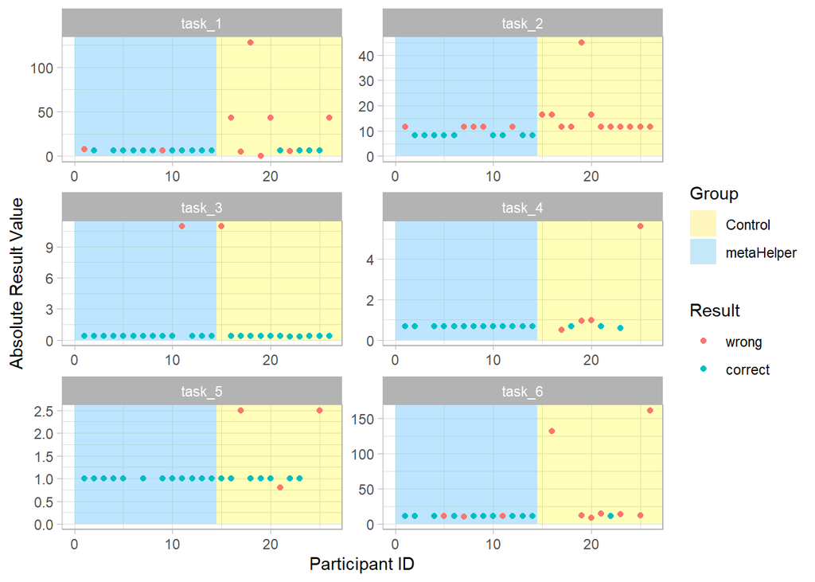

```r
dat_result  %>%
  mutate(result_correct = as_factor(result_correct) %>%
           recode("0" = "wrong", "1" = "correct")) %>%
  ggplot(aes(x = ID, y = abs(result))) +
  geom_rect(aes(xmin = min(ID), xmax = max(ID), ymin = 0, ymax = max(result), fill = group),  alpha = 0.2) +
  #first geom_rect is just used to create the legend
  geom_rect(data = group_shading_dat, aes(xmin = x_min, xmax = x_max, ymin = y_min, ymax = y_max, fill = Group),  alpha = 0.2) +
  geom_rect(xmin = 0, xmax = 14.5, ymin = 0, ymax = 500, fill = "#5BC0EB",  alpha = 0.02) +
  geom_rect(xmin = 14.5, xmax = 500, ymin = 0, ymax = 500, fill = "#FDE74C",  alpha = 0.02) +
  geom_point(aes(color = result_correct)) +
  xlab("Participant ID") +
  ylab("Absolute Result Value") +
  labs(color = "Result") +
  facet_wrap(~task, scales = "free", ncol = 2) +
  scale_fill_manual(name = "Group",
                    values = c("#FDE74C", "#5BC0EB")) +
  theme_light()
```

```r
ggsave("Exploratory_Plot_Result.png", width = 10, height = 12, dpi = 600)
```

# Statistical modelling - Correctness

## Task 1

Percentage correct control = 42.3

Percentage correct intervention = 70.5

Effect intervention logit = 1.1832716

Effect intervention logit lower = -0.0774978

Effect intervention logit lower = 2.4886168

## Task 2

Percentage correct control = 14.8

Percentage correct intervention = 52.5

Effect intervention logit = 1.8533976

Effect intervention logit lower = 0.5255242

Effect intervention logit lower = 3.260873

## Task 3

Percentage correct control = 90

Percentage correct intervention = 90.5

Effect intervention logit = 0.0565218

Effect intervention logit lower = -1.4912329

Effect intervention logit lower = 1.6034962

## Task 4

Percentage correct control = 38.9

Percentage correct intervention = 80.2

Effect intervention logit = 1.8513541

Effect intervention logit lower = 0.5725933

Effect intervention logit lower = 3.178263

## Task 5

Percentage correct control = 63.9

Percentage correct intervention = 79.6

Effect intervention logit = 0.7887643

Effect intervention logit lower = -0.5429974

Effect intervention logit lower = 2.1181092

## Task 6

Percentage correct control = 21.6

Percentage correct intervention = 60.3

Effect intervention logit = 1.7064317

Effect intervention logit lower = 0.4131683

Effect intervention logit lower = 3.051474

## All Tasks combined

```r
summary(result_all)$fixed["groupmetaHelper", ]
```

```
                Estimate Est.Error l-95% CI u-95% CI      Rhat Bulk_ESS
groupmetaHelper  2.52864 0.4541323 1.674045 3.468517 0.9999941 15793.82
                Tail_ESS
groupmetaHelper 11966.19
```

Overall probability for solution in control = 0.3116098

Overall probability for solution in intervention = 0.8501829 Overall probability for solution in intervention Lower Limit = 0.7071208 Overall probability for solution in intervention Lower Limit = 0.9355903

```r
summary(result_all)$fixed
```

```
                  Estimate Est.Error  l-95% CI  u-95% CI      Rhat Bulk_ESS
Intercept       -0.7926038 0.6133383 -2.059590 0.4011501 1.0002310  5809.25
groupmetaHelper  2.5286400 0.4541323  1.674045 3.4685172 0.9999941 15793.82
                 Tail_ESS
Intercept        7363.647
groupmetaHelper 11966.192
```

```r
summary(result_all)$fixed %>%
  data.frame() %>%
  mutate(across(Estimate:Rhat, round, digits = 2),
         across(Bulk_ESS:Tail_ESS, round, digits = 0)) %>%
  write.csv("result_correctness.csv")
```

## Posterior Samples

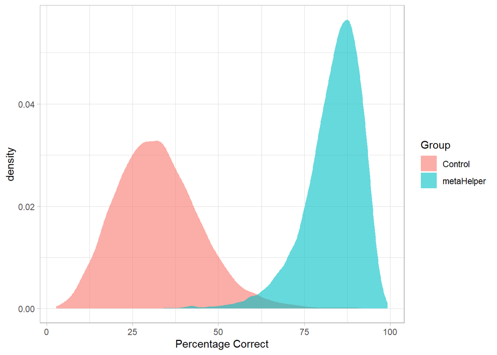

```r
posterior_samples <- as_draws_array(result_all)
tidy_samples <- tidy_draws(posterior_samples)

tidy_samples %>%
  mutate(metaHelper = logit2prob(b_Intercept + b_groupmetaHelper) *100,
         Control = logit2prob(b_Intercept) * 100) %>%
  select(metaHelper, Control) %>%
  pivot_longer(everything(), names_to = "Group") %>%
  ggplot(aes(x = value, fill = Group)) +
  geom_density(alpha = 0.6, color = NA) +
  xlab("Percentage Correct") +
  theme_light()
```

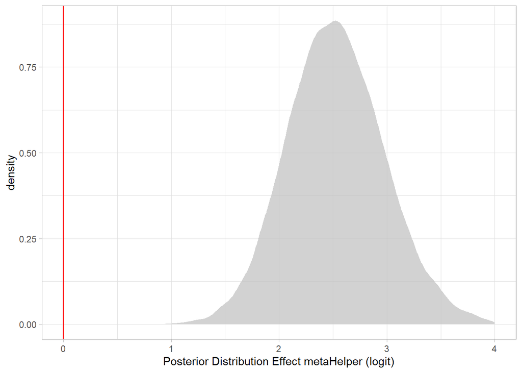

```r
tidy_samples %>%
  mutate(metaHelper = b_Intercept + b_groupmetaHelper,
         Control = b_Intercept) %>%
  ggplot(aes(x = b_groupmetaHelper)) +
  xlim(c(0, 4)) +
  geom_density(fill = "gray", alpha = 0.7, color = NA) +
  theme_light() +
  xlab("Posterior Distribution Effect metaHelper (logit)") +
  geom_vline(xintercept = 0, color = "red")
```

## Model Fit

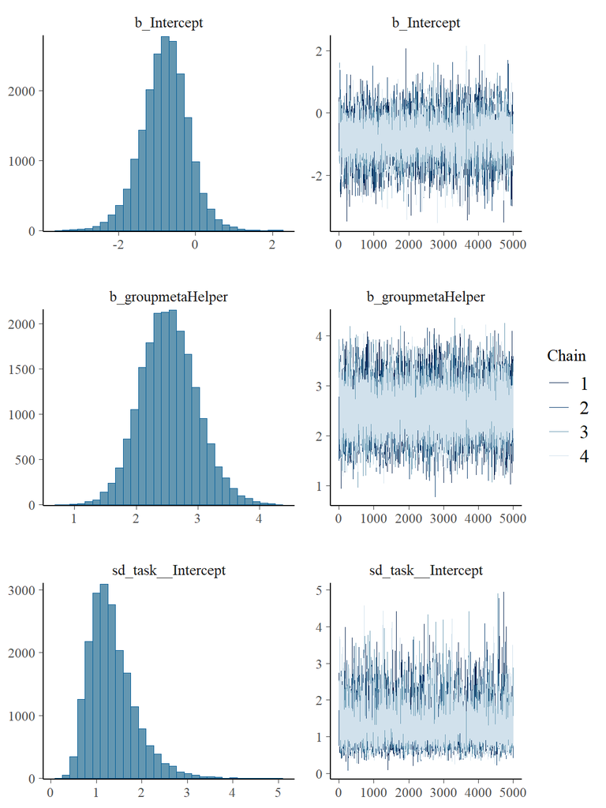

```r
plot(result_all)
```

# Statistical Modelling - Time

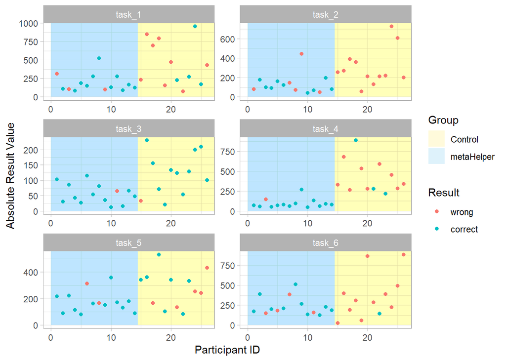

```r
group_shading_dat$time <- 0

dat_result %>%
  mutate(result_correct = as_factor(result_correct) %>%
           recode("0" = "wrong", "1" = "correct")) %>%
  ggplot(aes(x = ID, y = time)) +
  #first geom_rect is just used to create the legend
  geom_rect(data = group_shading_dat, aes(xmin = x_min, xmax = x_max, ymin = y_min, ymax = y_max, fill = Group),  alpha = 0.2) +
  geom_rect(xmin = 0, xmax = 14.5, ymin = 0, ymax = 5000, fill = "#5BC0EB",  alpha = 0.02) +
  geom_rect(xmin = 14.5, xmax = 500, ymin = 0, ymax = 5000, fill = "#FDE74C",  alpha = 0.02) +
  geom_point(aes(color = result_correct)) +
  facet_wrap(~task, scales = "free", ncol = 2) +
  xlab("Participant ID") +
  ylab("Absolute Result Value") +
  labs(color = "Result") +
  scale_fill_manual(name = "Group",
                    values = c("#FDE74C", "#5BC0EB")) +

  theme_light()
```

```r
ggsave("Exploratory_Plot_Result_Time.png", width = 10, height = 12, dpi = 600)
```

## Task 1

```r
summary(result_1_time)$fixed
```

```
                 Estimate Est.Error  l-95% CI  u-95% CI     Rhat Bulk_ESS
Intercept        438.7108  6.555006  425.8168  451.6472 1.000432 18799.11
groupmetaHelper -247.9174  8.828525 -265.2360 -230.6706 1.000099 19061.52
                Tail_ESS
Intercept       13817.26
groupmetaHelper 14075.86
```

## Task 2

```r
summary(result_2_time)$fixed
```

```
                 Estimate Est.Error  l-95% CI  u-95% CI      Rhat Bulk_ESS
Intercept        300.2941  5.077130  290.3301  310.2647 0.9999907 19989.16
groupmetaHelper -169.7095  6.929275 -183.3242 -156.0393 1.0002015 20313.97
                Tail_ESS
Intercept       14715.91
groupmetaHelper 14816.60
```

## Task 3

```r
summary(result_3_time)$fixed
```

```
                 Estimate Est.Error  l-95% CI  u-95% CI     Rhat Bulk_ESS
Intercept       121.29706  2.453284 116.49102 126.09388 1.000674 19187.24
groupmetaHelper -65.68158  3.376880 -72.25532 -59.08339 1.000170 19167.92
                Tail_ESS
Intercept       14135.07
groupmetaHelper 13622.76
```

## Task 4

```r
summary(result_4_time)$fixed
```

```
                 Estimate Est.Error  l-95% CI  u-95% CI     Rhat Bulk_ESS
Intercept        423.5661  4.941849  413.9127  433.3235 1.000155 18932.36
groupmetaHelper -328.8692  6.668480 -341.9028 -315.9085 1.000155 19137.34
                Tail_ESS
Intercept       13763.15
groupmetaHelper 14898.96
```

## Task 5

```r
summary(result_5_time)$fixed
```

```
                 Estimate Est.Error  l-95% CI  u-95% CI     Rhat Bulk_ESS
Intercept        275.8247  4.080030  267.7764 283.68429 1.000219 18330.54
groupmetaHelper -101.7408  5.513381 -112.4777 -90.85767 1.000195 19240.18
                Tail_ESS
Intercept       14489.33
groupmetaHelper 14455.38
```

## Task 6

```r
summary(result_6_time)$fixed
```

```
                 Estimate Est.Error  l-95% CI  u-95% CI     Rhat Bulk_ESS
Intercept        352.7491  6.195178  340.6404  364.9502 1.000043 19813.94
groupmetaHelper -117.7070  8.424186 -134.0240 -101.2519 1.000300 19619.98
                Tail_ESS
Intercept       14605.11
groupmetaHelper 14376.11
```

## All Tasks

```r
summary(result_time_all)
```

```
 Family: gaussian
  Links: mu = identity; sigma = identity
Formula: time ~ 1 + (1 | task) + group
   Data: dat_result (Number of observations: 156)
  Draws: 4 chains, each with iter = 10000; warmup = 5000; thin = 1;
         total post-warmup draws = 20000

Multilevel Hyperparameters:
~task (Number of levels: 6)
              Estimate Est.Error l-95% CI u-95% CI Rhat Bulk_ESS Tail_ESS
sd(Intercept)     0.01      0.01     0.00     0.04 1.00    21876    11407

Regression Coefficients:
                Estimate Est.Error l-95% CI u-95% CI Rhat Bulk_ESS Tail_ESS
Intercept         296.53     19.57   258.06   334.41 1.00    29278    16182
groupmetaHelper  -132.38     24.94  -180.51   -82.89 1.00    28186    16363

Further Distributional Parameters:
      Estimate Est.Error l-95% CI u-95% CI Rhat Bulk_ESS Tail_ESS
sigma   178.12     10.30   159.45   199.87 1.00    28514    15870

Draws were sampled using sampling(NUTS). For each parameter, Bulk_ESS
and Tail_ESS are effective sample size measures, and Rhat is the potential
scale reduction factor on split chains (at convergence, Rhat = 1).
```

```r
summary(result_time_all)$fixed %>%
  data.frame() %>%
  mutate(across(Estimate:Rhat, round, digits = 2),
         across(Bulk_ESS:Tail_ESS, round, digits = 0)) %>%
  write.csv("result_time.csv")
```

### Posterior Samples

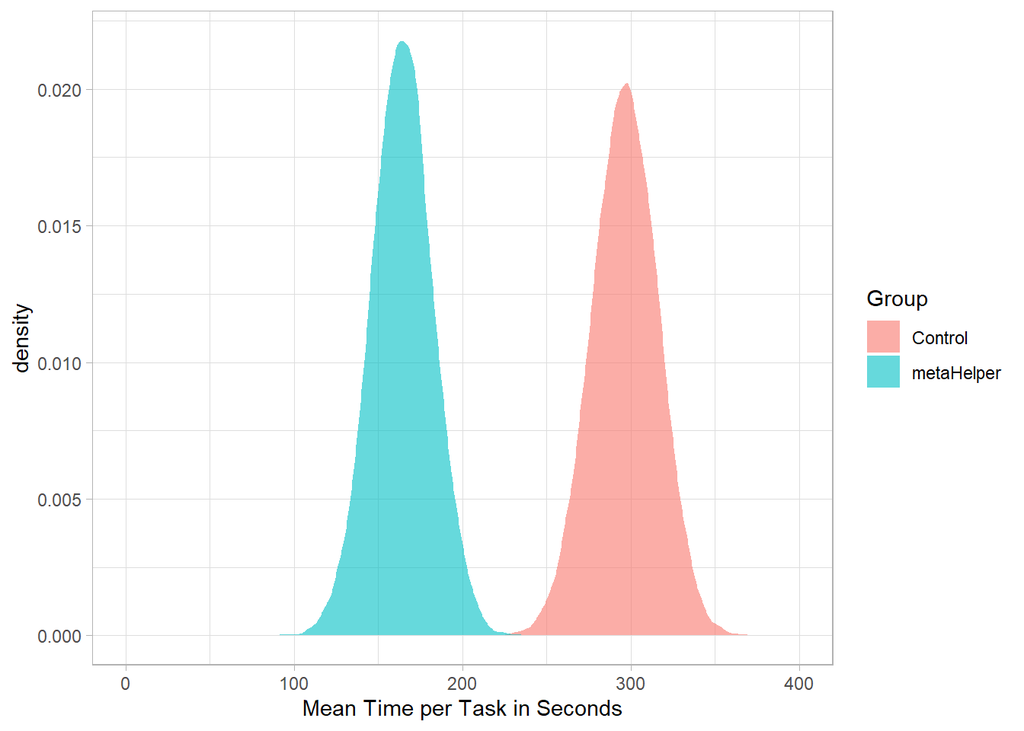

```r
posterior_samples <- as_draws_array(result_time_all)
tidy_samples <- tidy_draws(posterior_samples)

tidy_samples %>%
  mutate(metaHelper = b_Intercept + b_groupmetaHelper,
         Control = b_Intercept) %>%
  select(metaHelper, Control) %>%
  pivot_longer(everything(), names_to = "Group") %>%
  ggplot(aes(x = value, fill = Group)) +
  xlim(c(0, 400)) +
  geom_density(alpha = 0.6, color = NA) +
  xlab("Mean Time per Task in Seconds") +
  theme_light()
```

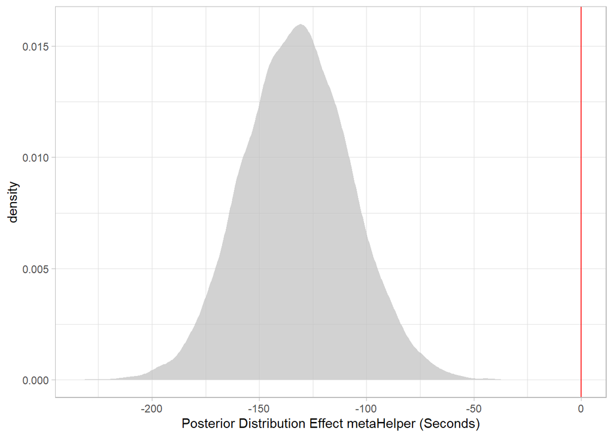

```r
ggsave("Result Time.png", width = 10, height = 5, dpi = 600)


tidy_samples %>%
  mutate(metaHelper = b_Intercept + b_groupmetaHelper,
         Control = b_Intercept) %>%
  ggplot(aes(x = b_groupmetaHelper)) +
  geom_density(fill = "gray", alpha = 0.7, color = NA) +
  theme_light() +
  xlab("Posterior Distribution Effect metaHelper (Seconds)") +
  geom_vline(xintercept = 0, color = "red")
```

### Model Fit

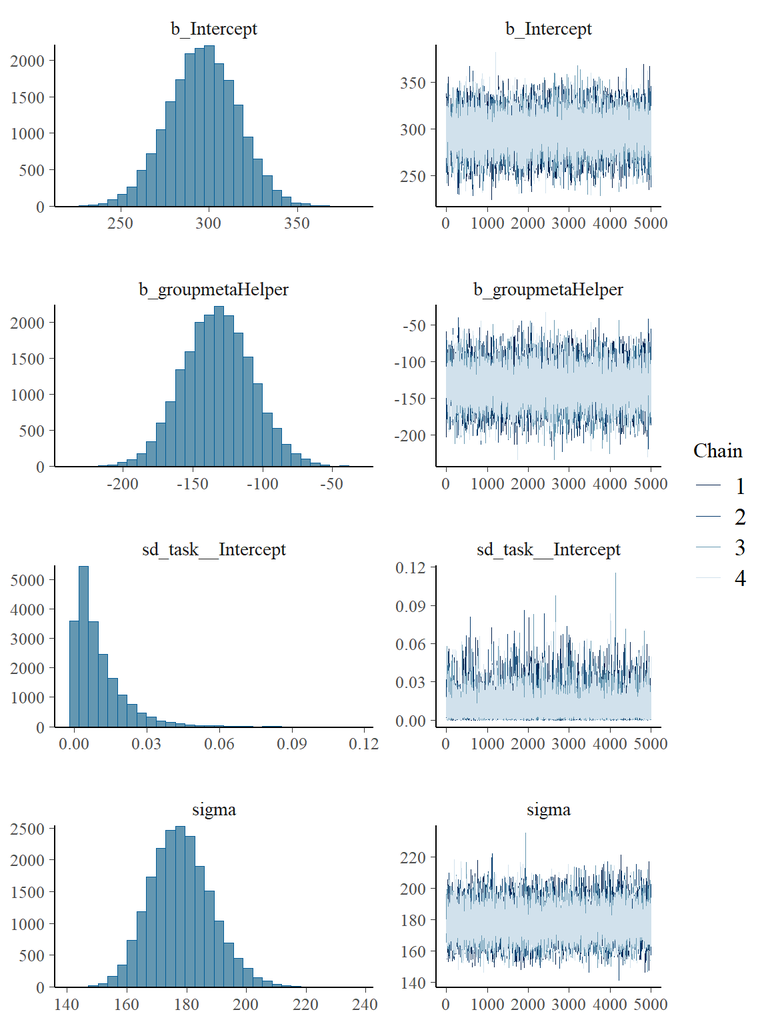

```r
plot(result_time_all)
```

## All Tasks - Taking Correctness into account

```r
summary(result_time_all_c)
```

```
 Family: gaussian
  Links: mu = identity; sigma = identity
Formula: time ~ 1 + (1 | task) + group * result_correct
   Data: dat_result (Number of observations: 156)
  Draws: 4 chains, each with iter = 10000; warmup = 5000; thin = 1;
         total post-warmup draws = 20000

Multilevel Hyperparameters:
~task (Number of levels: 6)
              Estimate Est.Error l-95% CI u-95% CI Rhat Bulk_ESS Tail_ESS
sd(Intercept)     0.01      0.01     0.00     0.04 1.00    18761     9860

Regression Coefficients:
                               Estimate Est.Error l-95% CI u-95% CI Rhat
Intercept                        323.69     22.54   279.34   367.40 1.00
groupmetaHelper                  -95.62     31.36  -157.24   -33.43 1.00
result_correct                   -56.33     29.71  -114.50     2.29 1.00
groupmetaHelper:result_correct   -29.96     35.00   -98.50    38.75 1.00
                               Bulk_ESS Tail_ESS
Intercept                         26597    17282
groupmetaHelper                   20802    15187
result_correct                    23536    15667
groupmetaHelper:result_correct    18415    15181

Further Distributional Parameters:
      Estimate Est.Error l-95% CI u-95% CI Rhat Bulk_ESS Tail_ESS
sigma   175.74     10.10   157.30   196.64 1.00    26383    15172

Draws were sampled using sampling(NUTS). For each parameter, Bulk_ESS
and Tail_ESS are effective sample size measures, and Rhat is the potential
scale reduction factor on split chains (at convergence, Rhat = 1).
```

### Posterior Samples

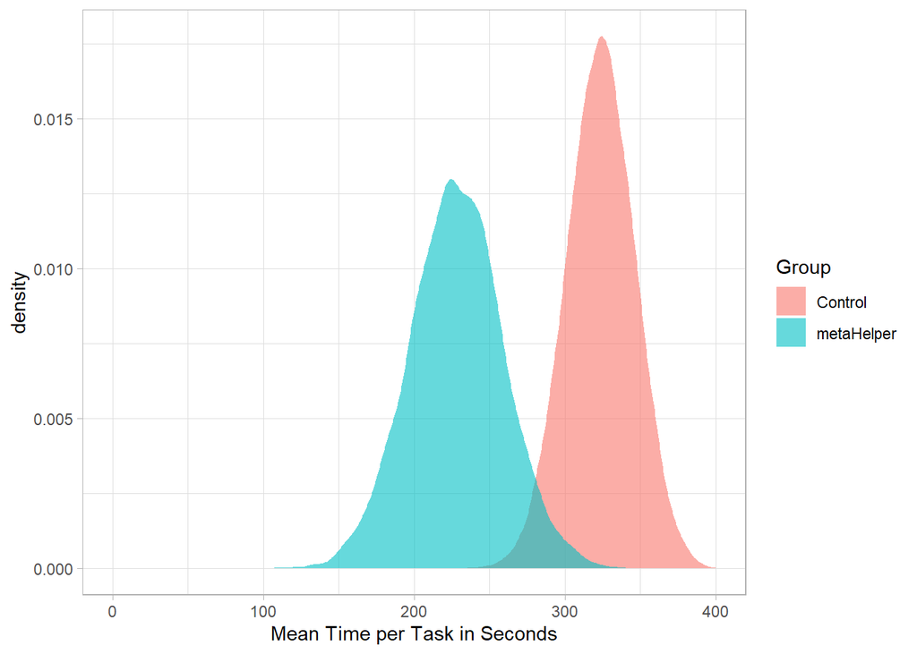

```r
posterior_samples <- as_draws_array(result_time_all_c)
tidy_samples <- tidy_draws(posterior_samples)

tidy_samples %>%
  mutate(metaHelper = b_Intercept + b_groupmetaHelper,
         Control = b_Intercept) %>%
  select(metaHelper, Control) %>%
  pivot_longer(everything(), names_to = "Group") %>%
  ggplot(aes(x = value, fill = Group)) +
  xlim(c(0, 400)) +
  geom_density(alpha = 0.6, color = NA) +
  xlab("Mean Time per Task in Seconds") +
  theme_light()
```

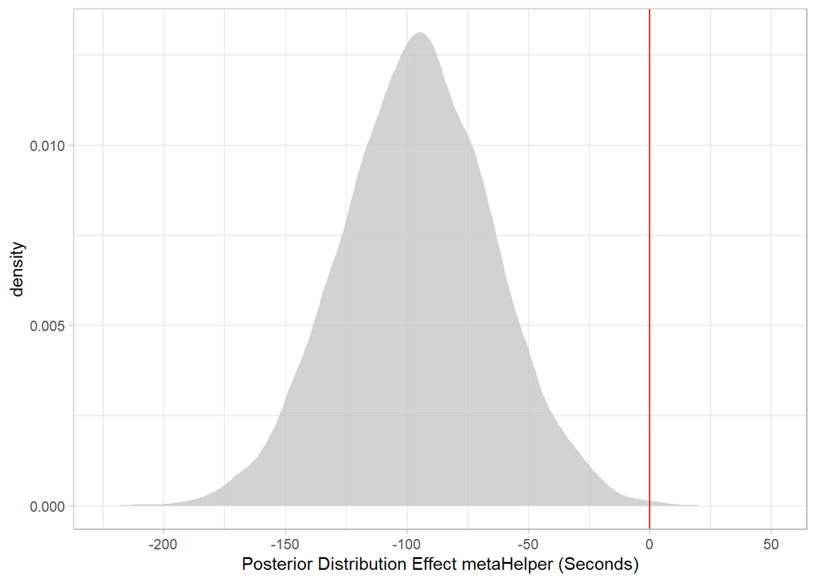

```r
tidy_samples %>%
  mutate(metaHelper = b_Intercept + b_groupmetaHelper,
         Control = b_Intercept) %>%
  ggplot(aes(x = b_groupmetaHelper)) +
  geom_density(fill = "gray", alpha = 0.7, color = NA) +
  theme_light() +
  xlab("Posterior Distribution Effect metaHelper (Seconds)") +
  geom_vline(xintercept = 0, color = "red")
```

### Model Fit

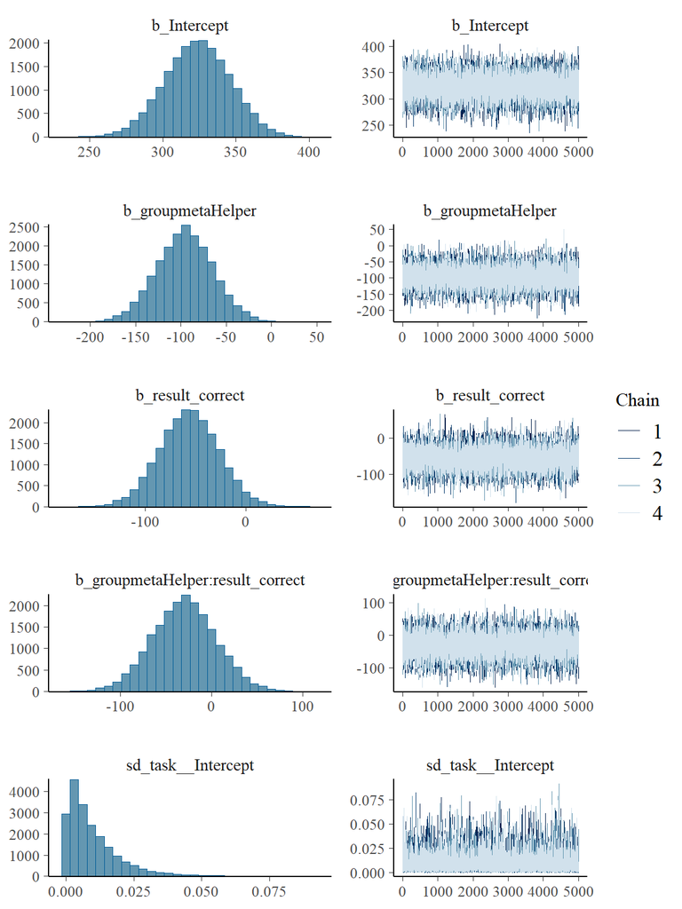

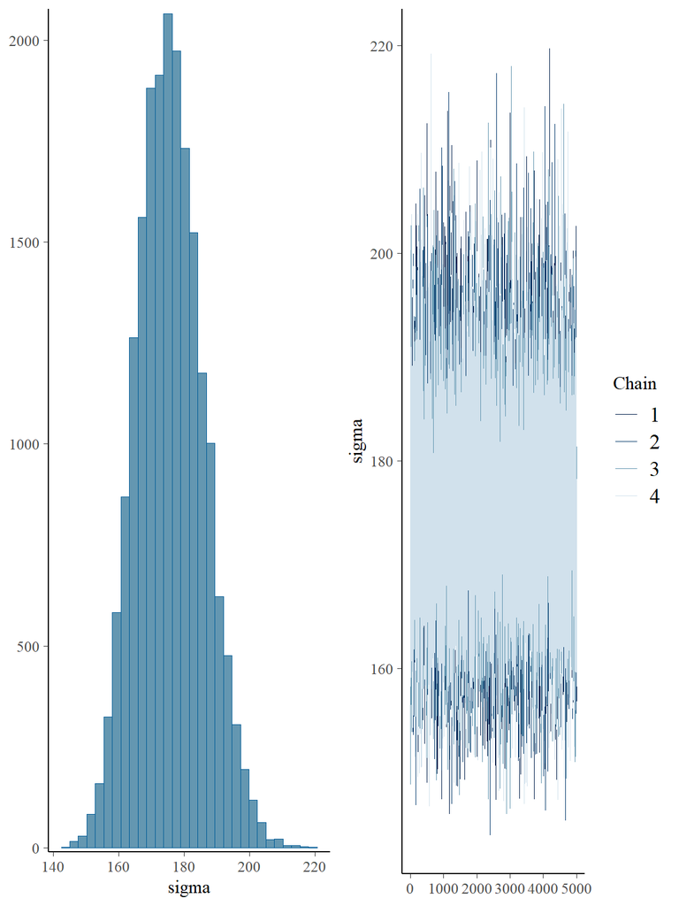

```r
plot(result_time_all_c, out.extra='stdout')
```

```r
summary(result_time_all_c)$fixed %>%
  data.frame() %>%
  mutate(across(Estimate:Rhat, round, digits = 2),
         across(Bulk_ESS:Tail_ESS, round, digits = 0)) %>%
  write.csv("result_time_and_correctness.csv")
```

# Sensitivity Analyses with different priors

## Correctness

### Increasing spread of priors for intercept and sd

```r
summary(result_all_sens1)
```

```
 Family: bernoulli
  Links: mu = logit
Formula: result_correct ~ 1 + (1 | task) + group
   Data: dat_result (Number of observations: 156)
  Draws: 4 chains, each with iter = 10000; warmup = 5000; thin = 1;
         total post-warmup draws = 20000

Multilevel Hyperparameters:
~task (Number of levels: 6)
              Estimate Est.Error l-95% CI u-95% CI Rhat Bulk_ESS Tail_ESS
sd(Intercept)     1.16      0.41     0.53     2.13 1.00     6645     9437

Regression Coefficients:
                Estimate Est.Error l-95% CI u-95% CI Rhat Bulk_ESS Tail_ESS
Intercept          -0.73      0.57    -1.91     0.38 1.00     6601     7774
groupmetaHelper     2.49      0.45     1.65     3.41 1.00    14861    12297

Draws were sampled using sampling(NUTS). For each parameter, Bulk_ESS
and Tail_ESS are effective sample size measures, and Rhat is the potential
scale reduction factor on split chains (at convergence, Rhat = 1).
```

```r
summary(result_all_sens1)$fixed %>%
  data.frame() %>%
  mutate(across(Estimate:Rhat, round, digits = 2),
         across(Bulk_ESS:Tail_ESS, round, digits = 0)) %>%
  write.csv("result_correctness_sens1.csv")
```

### Increasing spread of prior for the slope

```r
summary(result_all_sens2)$fixed %>%
  data.frame() %>%
  mutate(across(Estimate:Rhat, round, digits = 2),
         across(Bulk_ESS:Tail_ESS, round, digits = 0)) %>%
  write.csv("result_correctness_sens2.csv")
```

```r
summary(result_all_sens2)
```

```
 Family: bernoulli
  Links: mu = logit
Formula: result_correct ~ 1 + (1 | task) + group
   Data: dat_result (Number of observations: 156)
  Draws: 4 chains, each with iter = 10000; warmup = 5000; thin = 1;
         total post-warmup draws = 20000

Multilevel Hyperparameters:
~task (Number of levels: 6)
              Estimate Est.Error l-95% CI u-95% CI Rhat Bulk_ESS Tail_ESS
sd(Intercept)     1.36      0.52     0.62     2.62 1.00     5669     8287

Regression Coefficients:
                Estimate Est.Error l-95% CI u-95% CI Rhat Bulk_ESS Tail_ESS
Intercept          -0.79      0.60    -2.07     0.33 1.00     5362     8332
groupmetaHelper     2.54      0.46     1.67     3.47 1.00    15390    11822

Draws were sampled using sampling(NUTS). For each parameter, Bulk_ESS
and Tail_ESS are effective sample size measures, and Rhat is the potential
scale reduction factor on split chains (at convergence, Rhat = 1).
```

### Sensitivity Models Added in August 2025

#### SENSITIVITY Correctness random effect participant

```r
result_correct_sens_ID <- brm(
  result_correct ~ 1 + (1 | task) + (1 | ID) + group,
  family = bernoulli,
  prior = c(
    prior(normal(0, 1.5), class = Intercept),
    prior(exponential(1), class = sd),  # This now applies to both task and ID
    prior(normal(0, 50), class = b)
  ),
  control = list(adapt_delta = 0.9),
  iter = 10000,
  warmup = 5000,
  data = dat_result
)
# To see the results
summary(result_correct_sens_ID)
```

```
 Family: bernoulli
  Links: mu = logit
Formula: result_correct ~ 1 + (1 | task) + (1 | ID) + group
   Data: dat_result (Number of observations: 156)
  Draws: 4 chains, each with iter = 10000; warmup = 5000; thin = 1;
         total post-warmup draws = 20000

Multilevel Hyperparameters:
~ID (Number of levels: 26)
              Estimate Est.Error l-95% CI u-95% CI Rhat Bulk_ESS Tail_ESS
sd(Intercept)     0.40      0.30     0.02     1.12 1.00     7257     9164

~task (Number of levels: 6)
              Estimate Est.Error l-95% CI u-95% CI Rhat Bulk_ESS Tail_ESS
sd(Intercept)     1.40      0.54     0.63     2.72 1.00     8735    13232

Regression Coefficients:
                Estimate Est.Error l-95% CI u-95% CI Rhat Bulk_ESS Tail_ESS
Intercept          -0.83      0.63    -2.14     0.37 1.00     9227    10608
groupmetaHelper     2.63      0.52     1.66     3.72 1.00    19311    11992

Draws were sampled using sampling(NUTS). For each parameter, Bulk_ESS
and Tail_ESS are effective sample size measures, and Rhat is the potential
scale reduction factor on split chains (at convergence, Rhat = 1).
```

Results in percentage

```r
# 1. Extract all posterior draws from your model
tidy_draws_sens <- tidy_draws(result_correct_sens_ID)

# 2. Calculate the probability for each group and the difference for each draw
prob_summary <- tidy_draws_sens %>%
  summarise(
    # Probability for the Control group (from the Intercept)
    control_prob = median(logit2prob(b_Intercept)) * 100,
    control_lower = quantile(logit2prob(b_Intercept), 0.025) * 100,
    control_upper = quantile(logit2prob(b_Intercept), 0.975) * 100,

    # Probability for the metaHelper group (Intercept + effect)
    metaHelper_prob = median(logit2prob(b_Intercept + b_groupmetaHelper)) * 100,
    metaHelper_lower = quantile(logit2prob(b_Intercept + b_groupmetaHelper), 0.025) * 100,
    metaHelper_upper = quantile(logit2prob(b_Intercept + b_groupmetaHelper), 0.975) * 100,

    # The difference in percentage points
    difference_abs = median( (logit2prob(b_Intercept + b_groupmetaHelper) - logit2prob(b_Intercept)) ) * 100,
    difference_lower = quantile( (logit2prob(b_Intercept + b_groupmetaHelper) - logit2prob(b_Intercept)), 0.025 ) * 100,
    difference_upper = quantile( (logit2prob(b_Intercept + b_groupmetaHelper) - logit2prob(b_Intercept)), 0.975 ) * 100
  )

print(prob_summary)
```

```
# A tibble: 1 × 9
  control_prob control_lower control_upper metaHelper_prob metaHelper_lower
         <dbl>         <dbl>         <dbl>           <dbl>            <dbl>
1         30.7          10.5          59.2            85.6             63.1
# ℹ 4 more variables: metaHelper_upper <dbl>, difference_abs <dbl>,
#   difference_lower <dbl>, difference_upper <dbl>
```

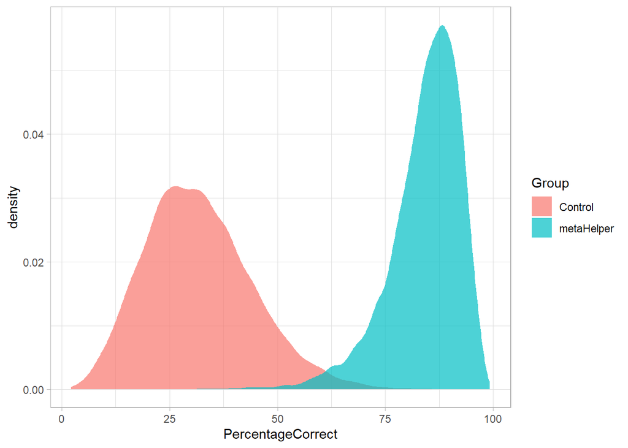

```r
tidy_samples_sens_ID <- tidy_draws(result_correct_sens_ID)

tidy_samples_sens_ID %>%
  mutate(
    # Calculate probability for the control group (the intercept)
    Control = logit2prob(b_Intercept) * 100,
    # Calculate probability for the metaHelper group (intercept + effect)
    metaHelper = logit2prob(b_Intercept + b_groupmetaHelper) * 100
  ) %>%
  # Keep only the columns we need for the plot
  select(Control, metaHelper) %>%
  # Reshape data into a long format for ggplot
  pivot_longer(everything(), names_to = "Group", values_to = "PercentageCorrect") %>%
  # Create the plot
  ggplot(aes(x = PercentageCorrect, fill = Group)) +
  geom_density(alpha = 0.7, color = NA) +
  theme_light()
```

## Time

### Different spread of priors for intercept and sd

```r
summary(result_time_sens1)
```

```
 Family: gaussian
  Links: mu = identity; sigma = identity
Formula: time ~ 1 + (1 | task) + group
   Data: dat_result (Number of observations: 156)
  Draws: 4 chains, each with iter = 10000; warmup = 5000; thin = 1;
         total post-warmup draws = 20000

Multilevel Hyperparameters:
~task (Number of levels: 6)
              Estimate Est.Error l-95% CI u-95% CI Rhat Bulk_ESS Tail_ESS
sd(Intercept)     0.00      0.00     0.00     0.01 1.00    23517    11311

Regression Coefficients:
                Estimate Est.Error l-95% CI u-95% CI Rhat Bulk_ESS Tail_ESS
Intercept         296.50     19.52   257.64   334.66 1.00    30746    15817
groupmetaHelper  -132.36     24.93  -180.92   -83.02 1.00    30633    15370

Further Distributional Parameters:
      Estimate Est.Error l-95% CI u-95% CI Rhat Bulk_ESS Tail_ESS
sigma   178.27     10.25   159.61   199.82 1.00    28318    14295

Draws were sampled using sampling(NUTS). For each parameter, Bulk_ESS
and Tail_ESS are effective sample size measures, and Rhat is the potential
scale reduction factor on split chains (at convergence, Rhat = 1).
```

```r
summary(result_time_sens1)$fixed %>%
  data.frame() %>%
  mutate(across(Estimate:Rhat, round, digits = 2),
         across(Bulk_ESS:Tail_ESS, round, digits = 0)) %>%
  write.csv("result_time_sens1.csv")
```

### Increasing spread of prior for the slope

```r
summary(result_time_sens2)
```

```
 Family: gaussian
  Links: mu = identity; sigma = identity
Formula: time ~ 1 + (1 | task) + group
   Data: dat_result (Number of observations: 156)
  Draws: 4 chains, each with iter = 10000; warmup = 5000; thin = 1;
         total post-warmup draws = 20000

Multilevel Hyperparameters:
~task (Number of levels: 6)
              Estimate Est.Error l-95% CI u-95% CI Rhat Bulk_ESS Tail_ESS
sd(Intercept)     0.01      0.01     0.00     0.04 1.00    24055    11752

Regression Coefficients:
                Estimate Est.Error l-95% CI u-95% CI Rhat Bulk_ESS Tail_ESS
Intercept         317.70     20.79   276.80   358.09 1.00    31433    15013
groupmetaHelper  -171.82     28.20  -226.63  -116.53 1.00    30387    15331

Further Distributional Parameters:
      Estimate Est.Error l-95% CI u-95% CI Rhat Bulk_ESS Tail_ESS
sigma   177.07     10.10   158.66   198.20 1.00    29900    14381

Draws were sampled using sampling(NUTS). For each parameter, Bulk_ESS
and Tail_ESS are effective sample size measures, and Rhat is the potential
scale reduction factor on split chains (at convergence, Rhat = 1).
```

```r
summary(result_time_sens2)$fixed %>%
  data.frame() %>%
  mutate(across(Estimate:Rhat, round, digits = 2),
         across(Bulk_ESS:Tail_ESS, round, digits = 0)) %>%
  write.csv("result_time_sens2.csv")
```

### Sensitivity Models Added in August 2025

#### SENSITIVITY 1 All Tasks with exponential 1

```r
summary(result_time_all)
```

```
 Family: gaussian
  Links: mu = identity; sigma = identity
Formula: time ~ 1 + (1 | task) + group
   Data: dat_result (Number of observations: 156)
  Draws: 4 chains, each with iter = 10000; warmup = 5000; thin = 1;
         total post-warmup draws = 20000

Multilevel Hyperparameters:
~task (Number of levels: 6)
              Estimate Est.Error l-95% CI u-95% CI Rhat Bulk_ESS Tail_ESS
sd(Intercept)     1.04      1.06     0.03     3.88 1.00    20165    10281

Regression Coefficients:
                Estimate Est.Error l-95% CI u-95% CI Rhat Bulk_ESS Tail_ESS
Intercept         296.49     19.80   257.59   335.04 1.00    26198    15105
groupmetaHelper  -132.54     25.28  -181.64   -82.61 1.00    26696    14644

Further Distributional Parameters:
      Estimate Est.Error l-95% CI u-95% CI Rhat Bulk_ESS Tail_ESS
sigma   178.15     10.26   159.58   199.58 1.00    26409    14234

Draws were sampled using sampling(NUTS). For each parameter, Bulk_ESS
and Tail_ESS are effective sample size measures, and Rhat is the potential
scale reduction factor on split chains (at convergence, Rhat = 1).
```

#### Posterior Samples

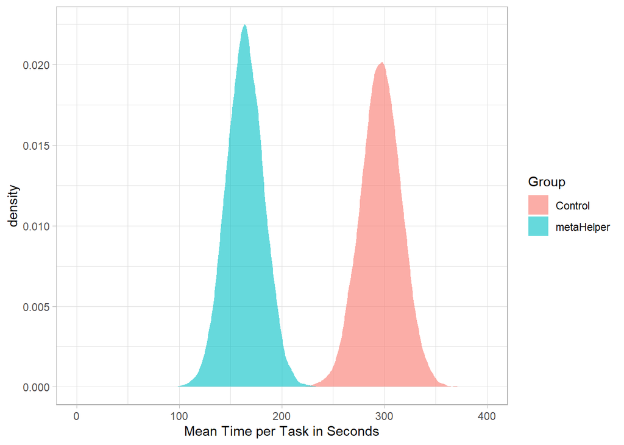

```r
posterior_samples <- as_draws_array(result_time_all)
tidy_samples <- tidy_draws(posterior_samples)

tidy_samples %>%
  mutate(metaHelper = b_Intercept + b_groupmetaHelper,
         Control = b_Intercept) %>%
  select(metaHelper, Control) %>%
  pivot_longer(everything(), names_to = "Group") %>%
  ggplot(aes(x = value, fill = Group)) +
  xlim(c(0, 400)) +
  geom_density(alpha = 0.6, color = NA) +
  xlab("Mean Time per Task in Seconds") +
  theme_light()
```

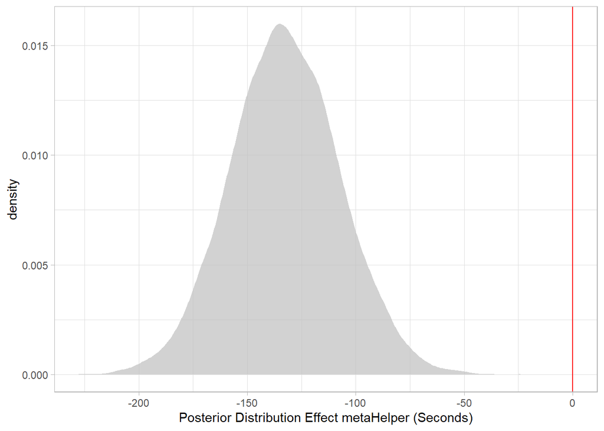

```r
ggsave("Result Time.png", width = 10, height = 5, dpi = 600)


tidy_samples %>%
  mutate(metaHelper = b_Intercept + b_groupmetaHelper,
         Control = b_Intercept) %>%
  ggplot(aes(x = b_groupmetaHelper)) +
  geom_density(fill = "gray", alpha = 0.7, color = NA) +
  theme_light() +
  xlab("Posterior Distribution Effect metaHelper (Seconds)") +
  geom_vline(xintercept = 0, color = "red")
```

#### SENSITIVITY 2 All Tasks with exponential 1 AND participant as random effect

```r
summary(result_time_all)
```

```
 Family: gaussian
  Links: mu = identity; sigma = identity
Formula: time ~ 1 + (1 | task) + (1 | ID) + group
   Data: dat_result (Number of observations: 156)
  Draws: 4 chains, each with iter = 10000; warmup = 5000; thin = 1;
         total post-warmup draws = 20000

Multilevel Hyperparameters:
~ID (Number of levels: 26)
              Estimate Est.Error l-95% CI u-95% CI Rhat Bulk_ESS Tail_ESS
sd(Intercept)     1.01      1.02     0.03     3.78 1.00    21001    11528

~task (Number of levels: 6)
              Estimate Est.Error l-95% CI u-95% CI Rhat Bulk_ESS Tail_ESS
sd(Intercept)     1.04      1.06     0.03     3.95 1.00    18741     9444

Regression Coefficients:
                Estimate Est.Error l-95% CI u-95% CI Rhat Bulk_ESS Tail_ESS
Intercept         296.24     19.82   257.18   334.71 1.00    31657    13971
groupmetaHelper  -132.21     25.52  -181.25   -81.28 1.00    32041    14727

Further Distributional Parameters:
      Estimate Est.Error l-95% CI u-95% CI Rhat Bulk_ESS Tail_ESS
sigma   178.25     10.40   159.54   200.22 1.00    30654    14947

Draws were sampled using sampling(NUTS). For each parameter, Bulk_ESS
and Tail_ESS are effective sample size measures, and Rhat is the potential
scale reduction factor on split chains (at convergence, Rhat = 1).
```

#### Posterior Samples

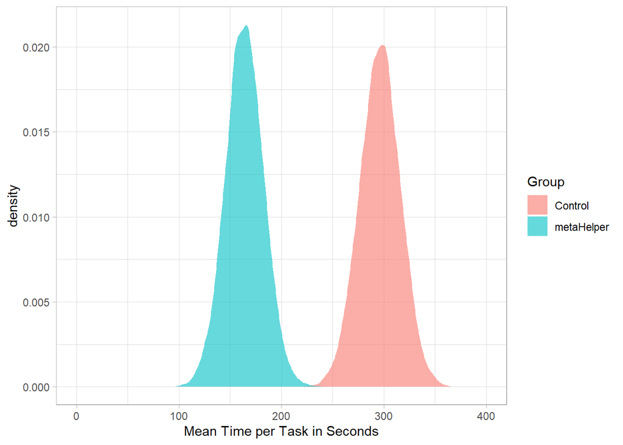

```r
posterior_samples <- as_draws_array(result_time_all)
tidy_samples <- tidy_draws(posterior_samples)

tidy_samples %>%
  mutate(metaHelper = b_Intercept + b_groupmetaHelper,
         Control = b_Intercept) %>%
  select(metaHelper, Control) %>%
  pivot_longer(everything(), names_to = "Group") %>%
  ggplot(aes(x = value, fill = Group)) +
  xlim(c(0, 400)) +
  geom_density(alpha = 0.6, color = NA) +
  xlab("Mean Time per Task in Seconds") +
  theme_light()
```

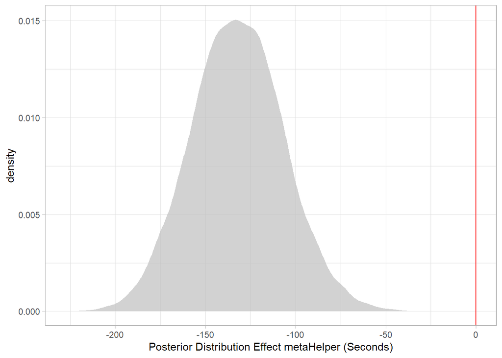

```r
ggsave("Result Time.png", width = 10, height = 5, dpi = 600)


tidy_samples %>%
  mutate(metaHelper = b_Intercept + b_groupmetaHelper,
         Control = b_Intercept) %>%
  ggplot(aes(x = b_groupmetaHelper)) +
  geom_density(fill = "gray", alpha = 0.7, color = NA) +
  theme_light() +
  xlab("Posterior Distribution Effect metaHelper (Seconds)") +
  geom_vline(xintercept = 0, color = "red")
```

#### SENSITIVITY 3 All Tasks with exponential 1 AND participant as random effect AND family = lognormal

```r
summary(result_time_all_logn)
```

```
 Family: lognormal
  Links: mu = identity; sigma = identity
Formula: time ~ 1 + group + (1 | task) + (1 | ID)
   Data: dat_result (Number of observations: 156)
  Draws: 4 chains, each with iter = 10000; warmup = 5000; thin = 1;
         total post-warmup draws = 20000

Multilevel Hyperparameters:
~ID (Number of levels: 26)
              Estimate Est.Error l-95% CI u-95% CI Rhat Bulk_ESS Tail_ESS
sd(Intercept)     0.33      0.08     0.19     0.51 1.00     6702     8759

~task (Number of levels: 6)
              Estimate Est.Error l-95% CI u-95% CI Rhat Bulk_ESS Tail_ESS
sd(Intercept)     0.55      0.23     0.27     1.13 1.00     6032     8989

Regression Coefficients:
                Estimate Est.Error l-95% CI u-95% CI Rhat Bulk_ESS Tail_ESS
Intercept           5.48      0.26     4.98     6.02 1.00     5069     8015
groupmetaHelper    -0.68      0.16    -0.98    -0.36 1.00     8142    11417

Further Distributional Parameters:
      Estimate Est.Error l-95% CI u-95% CI Rhat Bulk_ESS Tail_ESS
sigma     0.60      0.04     0.53     0.68 1.00    14519    13295

Draws were sampled using sampling(NUTS). For each parameter, Bulk_ESS
and Tail_ESS are effective sample size measures, and Rhat is the potential
scale reduction factor on split chains (at convergence, Rhat = 1).
```

```r
# population-level (no RE) summaries in seconds
newdat <- data.frame(group = factor(c("Control","metaHelper"),
                                    levels = c("Control","metaHelper")))

# Posterior draws: median time = exp(mu), mean time = E[Y] = exp(mu + 0.5*sigma^2)
mu_draws   <- posterior_linpred(result_time_all_logn, newdata = newdat,
                                re_formula = NA)          # on log scale (mu)
mean_draws <- posterior_epred(result_time_all_logn, newdata = newdat,
                              re_formula = NA)            # on response scale

# Convert to tidy frames
ctrl_med  <- exp(mu_draws[,1]);  meta_med  <- exp(mu_draws[,2])
ctrl_mean <- mean_draws[,1];     meta_mean <- mean_draws[,2]

summ <- tibble(
  group  = c("Control","metaHelper"),
  median = c(median(ctrl_med),  median(meta_med)),
  median_l = c(quantile(ctrl_med, .025), quantile(meta_med, .025)),
  median_u = c(quantile(ctrl_med, .975), quantile(meta_med, .975)),
  mean   = c(mean(ctrl_mean),   mean(meta_mean)),
  mean_l = c(quantile(ctrl_mean, .025),  quantile(meta_mean, .025)),
  mean_u = c(quantile(ctrl_mean, .975),  quantile(meta_mean, .975))
)

summ %>%
  mutate(across(-group, ~round(., 2))) %>%
  write.csv("result_time_lognormal_summary.csv", row.names = FALSE)
```

#### Posterior Samples

```r
draws <- as_draws_df(result_time_all_logn)

draws <- draws %>%
  mutate(time_ratio = exp(b_groupmetaHelper))  # <1 = faster with metaHelper

# Probability metaHelper is faster:
pr_faster <- mean(draws$time_ratio < 1)

# Numeric summary you can print/save
ratio_summ <- tibble(
  parameter = "time_ratio_metaHelper_vs_Control",
  median = median(draws$time_ratio),
  l95 = quantile(draws$time_ratio, .025),
  u95 = quantile(draws$time_ratio, .975),
  p_less_1 = pr_faster
)

ratio_summ %>%
  mutate(across(-parameter, ~round(., 3))) %>%
  write.csv("result_time_lognormal_ratio.csv", row.names = FALSE)
```

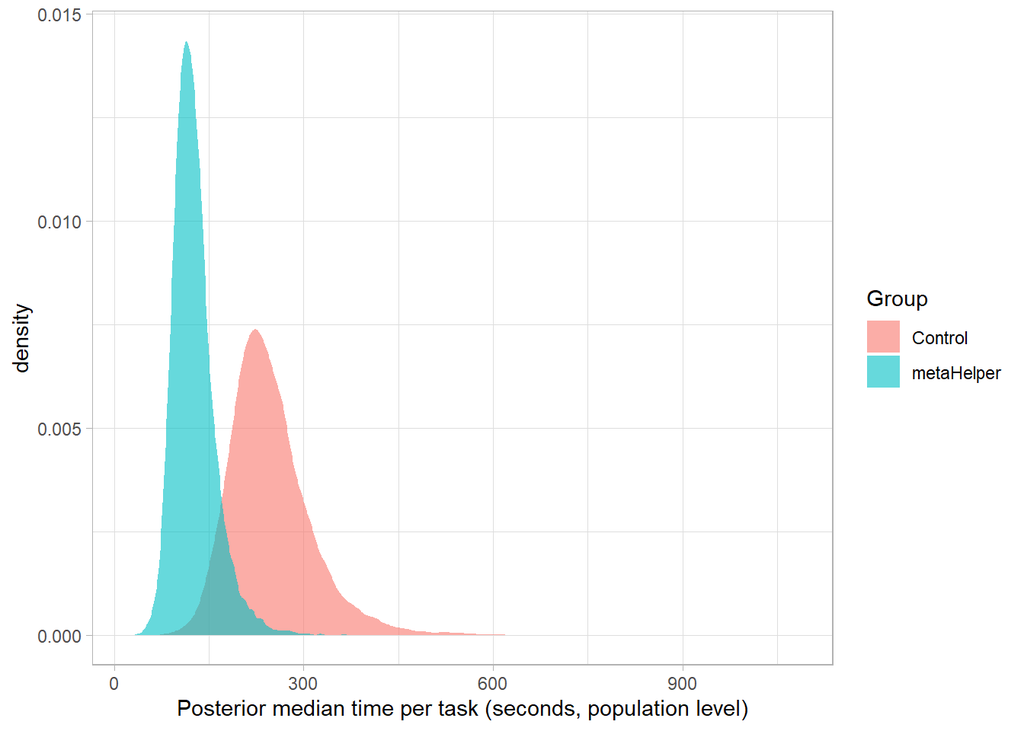

```r
# pick the fitted model object you have
fit_time <- if (exists("result_time_all_logn")) {
  result_time_all_logn
} else if (exists("result_time_all")) {
  result_time_all
} else {
  stop("No time model found: define result_time_all or result_time_all_logn first.")
}

# ensure contrast coding is what you expect
dat_result <- dat_result %>%
  mutate(group = factor(group, levels = c("Control","metaHelper")))
newdat <- tibble(group = factor(c("Control","metaHelper"),
                                levels = c("Control","metaHelper")))

fam <- family(fit_time)$family

# Posterior medians in SECONDS for each group (population level; no RE)
if (fam == "lognormal") {
  # mu is on log-time; median = exp(mu)
  mu_draws <- posterior_linpred(fit_time, newdata = newdat, re_formula = NA)
  ctrl_med  <- exp(mu_draws[, 1])
  meta_med  <- exp(mu_draws[, 2])
} else if (fam == "gaussian") {
  # use expected value directly (seconds)
  epred     <- posterior_epred(fit_time, newdata = newdat, re_formula = NA)
  ctrl_med  <- epred[, 1]
  meta_med  <- epred[, 2]
} else {
  stop(sprintf("Unsupported family: %s", fam))
}

# Build plotting data
med_df <- tibble(Control = ctrl_med, metaHelper = meta_med) |>
  pivot_longer(everything(), names_to = "Group", values_to = "MedianSeconds")

# Plot
ggplot(med_df, aes(x = MedianSeconds, fill = Group)) +
  geom_density(alpha = 0.6, color = NA) +
  xlab("Posterior median time per task (seconds, population level)") +
  theme_light()
```

```r
ggsave("Result_Time_Median_Density.png", width = 10, height = 5, dpi = 600)
```

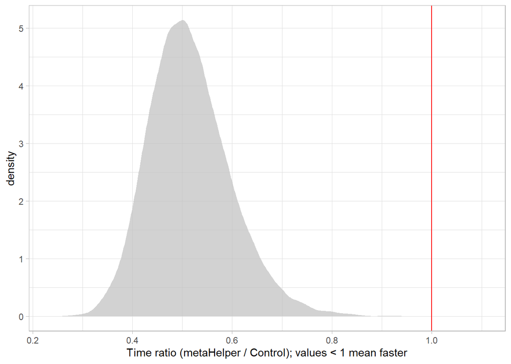

```r
ggplot(draws, aes(x = time_ratio)) +
  geom_density(fill = "gray", alpha = 0.7, color = NA) +
  geom_vline(xintercept = 1, color = "red") +
  xlab("Time ratio (metaHelper / Control); values < 1 mean faster") +
  theme_light()
```

```r
ggsave("Result_Time_Ratio_Density.png", width = 8, height = 5, dpi = 600)
```

# Removed Models

## Time

Lower bound prior for the intervention effect did not make sense

```r
summary(result_time_all_removed1)
```

```
 Family: gaussian
  Links: mu = identity; sigma = identity
Formula: time ~ 1 + (1 | task) + group
   Data: dat_result (Number of observations: 156)
  Draws: 4 chains, each with iter = 10000; warmup = 5000; thin = 1;
         total post-warmup draws = 20000

Multilevel Hyperparameters:
~task (Number of levels: 6)
              Estimate Est.Error l-95% CI u-95% CI Rhat Bulk_ESS Tail_ESS
sd(Intercept)     0.01      0.01     0.00     0.03 1.04      175      325

Regression Coefficients:
                Estimate Est.Error l-95% CI u-95% CI Rhat Bulk_ESS Tail_ESS
Intercept         225.19     15.07   195.24   253.67 1.05       68      230
groupmetaHelper     0.83      1.75     0.00     6.09 1.07       56       11

Further Distributional Parameters:
      Estimate Est.Error l-95% CI u-95% CI Rhat Bulk_ESS Tail_ESS
sigma   200.55     12.03   177.72   233.91 1.04      103       41

Draws were sampled using sampling(NUTS). For each parameter, Bulk_ESS
and Tail_ESS are effective sample size measures, and Rhat is the potential
scale reduction factor on split chains (at convergence, Rhat = 1).
```

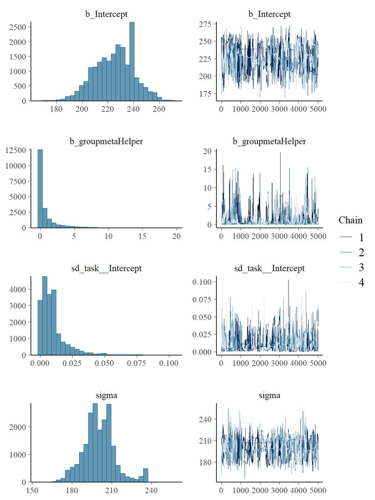

```r
plot(result_time_all_removed1)
```